# Reproducible Research: Peer Assessment 2

Justin Z

January 17, 2019

## Synopsis

The purpose of this document is to satisfy the requirements of the project 2 peer-graded assignment that is part of the Reproducible Research course within the Data Science Specialization on Coursera. As per the instructions the document must use the NOAA Storm Database to determine which types of events are most harmful to population health and which have the greatest economic consequences.

The `dplyr` package is required to execute this code. The input for this document is the data set which can be obtained from [here](https://d396qusza40orc.cloudfront.net/repdata%2Fdata%2FStormData.csv.bz2). The code will download the data file into the current working directory. The data will be subsetted and cleaned. It will then be explored to produce tables and plots that help answer the questions. The output is this report which is generated from a markdown file using `Knitr`.

## Data Processing

The original dataset is 902297 observations of 37 varibles, which if loaded is an object more than 400 Mb. Many of the variables are not needed to address the questions in this assingment, so they will be excluded to make this data easier to work with. First a vector of the `colClasses` is created which will be used in `read.csv` below to specify which columns to read in.

```r
library(dplyr)

# Check if the file exists in the current directory before downloading it again
file.name <- "ProjectData.csv.bz2"

if (!file.exists(file.name)) {
  url <- "https://d396qusza40orc.cloudfront.net/repdata%2Fdata%2FStormData.csv.bz2"
  download.file(url, file.name)
  rm(url)
}

# Specify the columns to keep and their data types
keep.cols <- c("NULL", "character", rep("NULL", 5), "factor", rep("NULL", 14),
               rep("numeric", 3), "factor", "numeric", "factor", rep("NULL", 9))

# Read in only the specified columns of data
data <- read.csv(file.name, colClasses = keep.cols)  # 902297 obs of 8 variables
rm(file.name, keep.cols)

# Preview the unmodified data
as_tibble(data)
```

```
## # A tibble: 902,297 x 8
##    BGN_DATE EVTYPE FATALITIES INJURIES PROPDMG PROPDMGEXP CROPDMG
##    <chr>    <fct>       <dbl>    <dbl>   <dbl> <fct>        <dbl>
##  1 4/18/19~ TORNA~          0       15    25   K                0
##  2 4/18/19~ TORNA~          0        0     2.5 K                0
##  3 2/20/19~ TORNA~          0        2    25   K                0
##  4 6/8/195~ TORNA~          0        2     2.5 K                0
##  5 11/15/1~ TORNA~          0        2     2.5 K                0
##  6 11/15/1~ TORNA~          0        6     2.5 K                0
##  7 11/16/1~ TORNA~          0        1     2.5 K                0
##  8 1/22/19~ TORNA~          0        0     2.5 K                0
##  9 2/13/19~ TORNA~          1       14    25   K                0
## 10 2/13/19~ TORNA~          0        0    25   K                0
## # ... with 902,287 more rows, and 1 more variable: CROPDMGEXP <fct>
```

A preview of the data is shown above. It is not yet suitable for analysis - many of the data types need to be modified or the variables need to be transformed. In the next several sections each of the 8 variables will be addressed individually. The first variable is `BGN_DATE` which contains date and time data as characters. As the time is not relevent to this analysis, the date will be extracted and stored as the `date` data type.

```r
# Extract the date from BGN_DATE and store as a date
data <- as_tibble(data) %>%
  mutate(date = as.POSIXct(BGN_DATE, format = "%m/%d/%Y %H:%M:%S")) %>%
  mutate(date = as.Date(date)) %>%  # Change from a POSIXct to a date data type
  select(-BGN_DATE)  # Drop the original variable, 902297 obs of 8 variables
```

The next variable is `EVTYPE` which contains the event types. According to the [documentation](https://d396qusza40orc.cloudfront.net/repdata%2Fpeer2_doc%2Fpd01016005curr.pdf) from the National Weather Service there are 48 official event types. Checking the actual data shows 985 unique event types in the database, and these are due to inconsistencies in how the event types were written. Ideally the event types would be mapped to the correct intended event type, and this will be partially completed in the next section. First a reference table is created which contains the actual 48 event types from the documentation. A `key` variable is used to simplify the mapping in the following step, and a 49th event type is added to capture the “unmapped” EVTYPES.

```r
# Create a reference table of the actual event types from the documentation.
actual.evtypes <- as_tibble(seq(1:49)) %>%  # A numerical sequence for the "key"
  rename(key = value) %>%  # 49 obs of 1 variable
  mutate(event.type = c("Astronomical Low Tide", "Avalanche", "Blizzard",
                        "Coastal Flood", "Cold/Wind Chill", "Debris Flow",
                        "Dense Fog", "Dense Smoke", "Drought", "Dust Devil",
                        "Dust Storm", "Excessive Heat",
                        "Extreme Cold/Wind Chill", "Flash Flood", "Flood",
                        "Frost/Freeze", "Funnel Cloud", "Freezing Fog", "Hail",
                        "Heat", "Heavy Rain", "Heavy Snow", "High Surf",
                        "High Wind", "Hurricane (Typhoon)", "Ice Storm",
                        "Lake-Effect Snow", "Lakeshore Flood", "Lightning",
                        "Marine Hail", "Marine High Wind", "Marine Strong Wind",
                        "Marine Thunderstorm Wind", "Rip Current", "Seiche",
                        "Sleet", "Storm Surge/Tide", "Strong Wind",
                        "Thunderstorm Wind", "Tornado", "Tropical Depression",
                        "Tropical Storm", "Tsunami", "Volcanic Ash",
                        "Waterspout", "Wildfire", "Winter Storm",
                        "Winter Weather", "Unmapped"))  # From NWS document
```

Next the observed event types must be mapped to the actual (intended) event types. Below, the event types are sorted by decreasing count and then manually coded with the `key` variable created above. Not all 985 types will be manually mapped - those that are not will be lumped into a standalone category called `Unmapped`. By mapping the first 175 manually, one can see that only 1650 (or 0.18%) total events remained unmapped. In this way all of the data rows are still preserved, but at the expense of a small fraction of events being obscured into the `Unmapped` event type.

```r
# Manually map the first 175 of the observed EVTYPES
observed.evtypes <- data %>%
  group_by(EVTYPE) %>%  # 902297 obs of 8 variables
  summarize(count = n()) %>%  # 985 obs of 2 variables
  arrange(desc(count)) %>%  # Sort by descending count of EVTYPE
  mutate(key = c(19, 39, 39, 40, 14, 15, 39, 24, 29, 22, 21, 47, 47, 17, 33, 33,
                 45, 24, 14, 46, 3, 9, 26, 12, 24, 46, 16, 7, 48, 19, 13, 20,
                 23, 42, 14, 13, 4, 27, 14, 6, 22, 5, 7, 34, 30, 11, 2, 24, 34,
                 37, 16, 14, 23, 13, 24, 39, 1, 25, 14, 48, 37, 12, 4, 10, 31,
                 12, 15, 4, 48, 14, 48, 25, 17, 23, 12, 16, 12, 13, 13, 16, 30,
                 41, 36, 9, 16, 24, 39, 32, 49, 19, 17, 18, 39, 12, 39, 4, 45,
                 21, 24, 21, 48, 14, 48, 22, 22, 14, 19, 16, 24, 21, 22, 27, 14,
                 39, 24, 28, 16, 39, 13, 12, 14, 44, 27, 48, 35, 16, 4, 43, 13,
                 22, 40, 21, 48, 19, 13, 13, 22, 26, 21, 21, 22, 16, 21, 39, 12,
                 19, 19, 39, 12, 47, 36, 13, 24, 16, 21, 13, 8, 48, 25, 13, 8,
                 24, 36, 36, 39, 12, 12, 45, 9, 48, 36, 21, 23, 25, 6,
                 rep(49, 810))) %>%  # Manually mapped 175 types, 985 obs of 3
  select(-count) %>%  # Drop the count variable, 985 obs of 2 variables
  inner_join(actual.evtypes, by = "key") %>%  # Add actual evtypes for each key
  select(-key)  # Drop the key variable, now it is a table mapping EVTYPES
```

The table created above can be used as a reference table mapping the actual EVTYPES from the dataset to the intended EVTYPES. In the section below the `EVTYPE` variable in the original data will be replaced by the mapped event type.

```r
# Replace the original EVTYPES with the manually mapped EVTYPES
data <- data %>%  # 902297 obs of 8 variables
  inner_join(observed.evtypes, by = "EVTYPE") %>%  # Add column of mapped evtype
  select(-EVTYPE) %>%  # Drop column of original EVTYPE
  mutate(event.type = as.factor(event.type))  # Change from chr to factor var

rm(actual.evtypes, observed.evtypes)
```

With the EVTYPES properly handled, the next variables can be addressed: `FATALITIES` and `INJURIES`. `read.csv` could not load these as integers originally, but they will be converted to integers now to reduce object size.

```r
# Convert fatalities and injuries back into integers
data <- data %>%
  mutate(fatalities = as.integer(FATALITIES)) %>%  # Add column for integer vals
  select(-FATALITIES) %>%  # Drop original column
  mutate(injuries = as.integer(INJURIES)) %>%  # Add column for integer values
  select(-INJURIES)  # Drop original column
```

Next the `PROPDMG` and `PROPDMGEXP` variables will be combined to create a single value that represents the amount of property damage. In order to achieve this the `PROPDMGEXP` values must be handled correctly. The article from this [link](https://rstudio-pubs-static.s3.amazonaws.com/58957_37b6723ee52b455990e149edde45e5b6.html) was used as a guide in handling this variable. Near the end of the article one can see that for numeric values of `PROPDMGEXP` the value itself should be used as the ones digit of the final result. For simplicity the approach outlined at the beginning of the report was employed instead. Due to the small sample size and small magnitude of these substitutions the impact of this simplified technique is expected to be small. These steps will be repeated for the `CROPDMG` and `CROPDMGEXP` variables as well.

```r
# First create a reference table for the PROPDMGEXP values and multipliers
prop.ref <- as_tibble(levels(data$PROPDMGEXP)) %>%  # Get the different levels
  mutate(PROPDMGEXP = as.factor(value)) %>%  # Add a column converting to factor
  select(-value) %>%  # Drop the original column of chr type, with default name
  arrange(PROPDMGEXP) %>%  # Ensure rows are sorted correctly
  mutate(prop.multiplier = c(0, 0, 0, 1, rep(10, 9), 1000000000, 100, 100, 1000,
                             rep(1000000, 2)))  # Manually map the multipliers

# Next create a reference table for the CROPDMGEXP values and multipliers
crop.ref <- as_tibble(levels(data$CROPDMGEXP)) %>%  # 9 obs of 1 variable
  mutate(CROPDMGEXP = as.factor(value)) %>%  # 9 obs of 2 variables
  select(-value) %>%  # 9 obs of 1 variable
  arrange(CROPDMGEXP) %>%  # Ensure rows are sorted correctly
  mutate(crop.multiplier = c(0, 0, 10, 10, 1000000000, 1000, 1000,
                             rep(1000000, 2)))  # 9 obs of 2 variables

# Replace the PROPDMG variables
data <- data %>%  # 902927 obs of 8 variables
  inner_join(prop.ref, by = "PROPDMGEXP") %>%  # Add column with the multiplier
  mutate(prop.dmg = PROPDMG * prop.multiplier) %>%  # Add column for the damage
  select(-c(PROPDMG, PROPDMGEXP, prop.multiplier))  # Drop the unneeded columns

# Replace the CROPDMG variables
data <- data %>%  # 902927 obs of 7 variables
  inner_join(crop.ref, by = "CROPDMGEXP") %>%  # 903927 obs of 8 variables
  mutate(crop.dmg = CROPDMG * crop.multiplier) %>%  # 903927 obs of 9 variables
  select(-c(CROPDMG, CROPDMGEXP, crop.multiplier))  # 903927 obs of 6 variables

rm(prop.ref, crop.ref)
```

At this point the columns have all been dealt with, and next the rows will be considered. An important trend about the distribution of the event types is revealed.

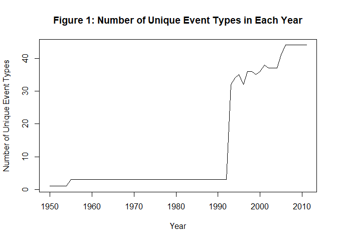

```r
# Check how data was collected over the years
table.0 <- data %>%
  mutate(year = format(date, "%Y")) %>%  # Extract the year from the date
  group_by(year, event.type) %>%
  summarize %>%  # Summarize the data by unique event types in each year
  group_by(year) %>%  # Drop the event.type group
  summarize(count = n())  # Count the number of unique events in each year

# Plot the number of unique events in each year
plot(table.0$year, table.0$count, type = "l", xlab = "Year",
     ylab = "Number of Unique Event Types",
     main = "Figure 1: Number of Unique Event Types in Each Year")
```

By viewing Figure 1 above, one can see that in the 62 year history of the data that in the first 43 years there were three or fewer event types every year. A likely explanation for this is that the other categories of event types were not captured during this time. If viewed in aggregate this fact could skew the analysis by giving too much weight to these three event types. For the fairest comparison of the event types the first 43 years of data will be ignored.

```r
# Drop the first 43 years of data
data <- data %>%  # 902297 obs of 6 variables
  filter(date > "1992-12-31") %>%  # 714738 obs of 6 variables
  arrange(date)  # Sort by increasing date

# Preview the data which is now ready for analysis
data
```

```
## # A tibble: 714,738 x 6
##    date       event.type fatalities injuries prop.dmg crop.dmg
##    <date>     <fct>           <int>    <int>    <dbl>    <dbl>
##  1 1993-01-01 Heavy Snow          0        0        0        0
##  2 1993-01-01 Heavy Snow          0        0        0        0
##  3 1993-01-01 Heavy Snow          0        0        0        0
##  4 1993-01-01 High Wind           0        0        0        0
##  5 1993-01-01 Avalanche           0        0        0        0
##  6 1993-01-01 Avalanche           0        0        0        0
##  7 1993-01-01 Avalanche           0        0        0        0
##  8 1993-01-01 Flood               0        0  5000000        0
##  9 1993-01-01 Flood               0        0     5000        0
## 10 1993-01-01 Ice Storm           0        0        0        0
## # ... with 714,728 more rows
```

## Results

The first question in the assignment is: across the US which types of events are most harmful with respect to population health?

In the instructions the term “harmful” is left to interpretation - it could mean most fatalities, most injuries, or a blended combination of both. Since injuries are roughly 10x more numerous, combining the two variables would just obscure the fatality data. The fatality and injury data will be presented side-by-side.

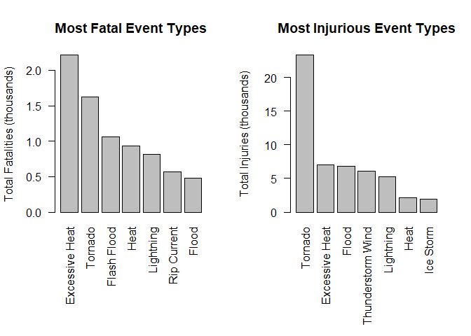

```r
# Create a table of the most fatal event types, sorted by total fatalities
table.1a <- data %>%  # 714738 obs of 6 variables
  group_by(event.type) %>%
  summarize(total.fatalities = sum(fatalities) / 1000) %>%  # Scale to 1000's
  arrange(desc(total.fatalities)) %>%  # Sort by descending fatalities
  slice(1:7)  # Subset only the first seven rows, the most harmful events

# Create a table of the most injurious event types, sorted by total injuries
table.1b <- data %>%  # 714738 obs of 6 variables
  group_by(event.type) %>%
  summarize(total.injuries = sum(injuries) / 1000) %>%  # 48 obs of 2 variables
  arrange(desc(total.injuries)) %>%  # Sort by descending injuries
  slice(1:7)  # 7 obs of 2 variables

# Create a figure that displays both the fatality and injury plots
par(mar = c(9.1, 4.1, 4.1, 2.1), mfrow = c(1, 2), las = 2)  # Setup plot space

# Add the plot of the fatality data
barplot(table.1a$total.fatalities, names.arg = table.1a$event.type,
        ylab = "Total Fatalities (thousands)", main = "Most Fatal Event Types")

# Add the plot of the injury data
barplot(table.1b$total.injuries, names.arg = table.1b$event.type,
        ylab = "Total Injuries (thousands)",
        main = "Most Injurious Event Types")
```

In Figure 2 above one can see the seven most harmful event types in each category. The event types that appear in the top seven in both fatalities and injuries are: Excessive Heat, Tornado, Heat, Lightning, and Flood.

The second question in the assignment is: across the US which types of events have the greatest economic consequences?

Given the different magnitudes of the data, combining the varibles would obscure the crop damage data. Instead, the property damage and crop damage data will be presented side-by-side.

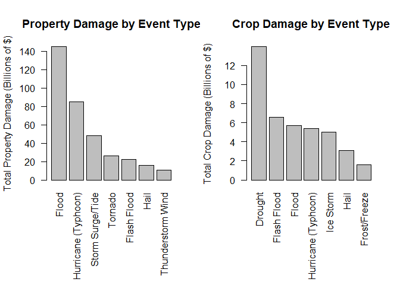

```r
# Create a table of the event types that are most damaging to property
table.2a <- data %>%  # 714738 obs of 6 variables
  group_by(event.type) %>%
  summarize(total.prop.dmg = sum(prop.dmg) / 1000000000) %>%  # Scale to billion
  arrange(desc(total.prop.dmg)) %>%
  slice(1:7)  # Subset only the first seven rows, the most damaging event types

# Create a table of the event types that are most damaging to crops
table.2b <- data %>%  # 714738 obs of 6 variables
  group_by(event.type) %>%
  summarize(total.crop.dmg = sum(crop.dmg) / 1000000000) %>%  # 48 obs of 2 vars
  arrange(desc(total.crop.dmg)) %>%
  slice(1:7)  # 7 obs of 2 variables

# Create a figure that displays both the property damage and crop damage plots
par(mar = c(9.1, 4.1, 4.1, 2.1), mfrow = c(1, 2), las = 2)  # Setup plot space

# Add the plot of the property damage data
barplot(table.2a$total.prop.dmg, names.arg = table.2a$event.type,
        ylab = "Total Property Damage (Billions of $)",
        main = "Property Damage by Event Type")

# Add the plot of the crop damage data
barplot(table.2b$total.crop.dmg, names.arg = table.2b$event.type,
        ylab = "Total Crop Damage (Billions of $)",
        main = "Crop Damage by Event Type")
```

In Figure 3 above one can see the seven most damaging event types in each category. The event types that appear in the top seven in both property and crop damage are: Flood, Hurricane (Typhoon), Flash Flood, and Hail.